# TE analysis in morulae embryos injected and nonInjected w active/dead-Btgh

Sara Formichetti

EMBL Rome  
sara.formichetti@embl.it

June 13th, 2022

# 1 Reading the data

The input files are:

- the output tables made by featureCounts (run in rule ‘count_on_TE’ of the TE_RNASeq.Snakefile), which contain read counts of all repetitive elements (i.e. all repNames) for all samples
- the repetitive elements annotation ../../data/annotations/RepeatMasker_RepeatLibrary20140131_mm10.noGenes.noSimple.bed used for featureCounts command, that is used to retrieve repFamily and repClass for each repName. The annotation I chose is the RepeatMasker most updated library to Nov2020, from which ‘Simple repeats’ and ‘Low complexity regions’ are removed in rule filter_TE_annotation rule of TE_RNASeq.Snakefile
- a table with total number of reads per sample in the raw fastq files
- the samples’ table, containing info on experimental design:

# 2 Analysis at family level

## 2.1 FPKM for each family of Repetitive Elements

For each family of Repetitive Elements (in case of elements with no repFamily name or repFamilies belonging to more than one repClass I use repClass) I compute **FPKM** values, as follows: for each sample:

- I compute the sum of counts for all elements belonging to that repFamily
- I divide this sum by the total number of reads for that sample and multiply by 10⁶
- I divide this number by the total sum of lengths (in Kb) of the elements belonging to that repFamily –> FPKM
- When specified, **I subtract from each FPKM the total FPKM of all transposons belonging to the DNA repClass**

## 2.2 Heatmaps

The heatmaps are scaled by rows.

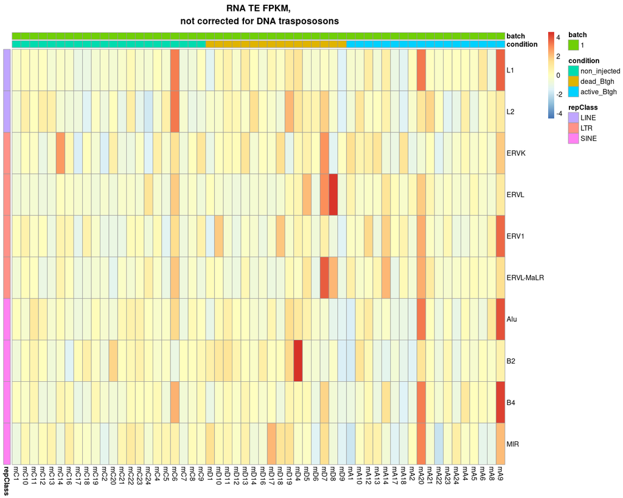

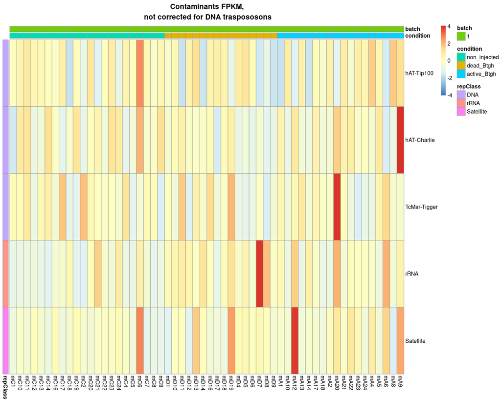

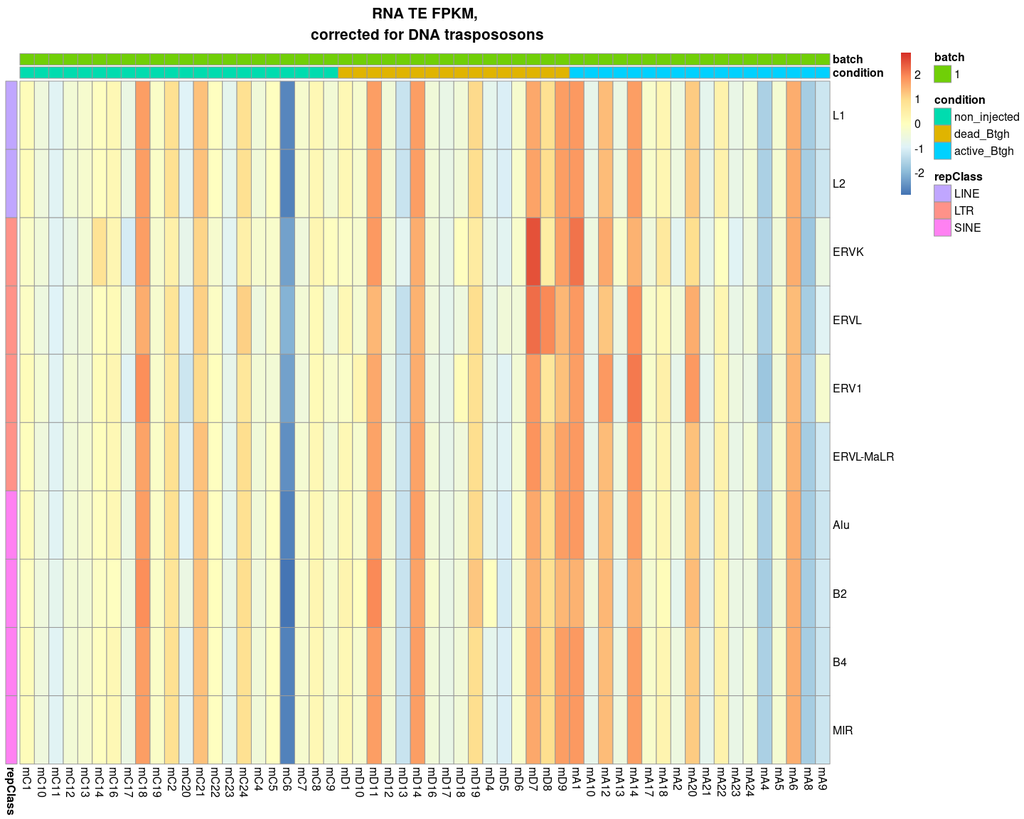

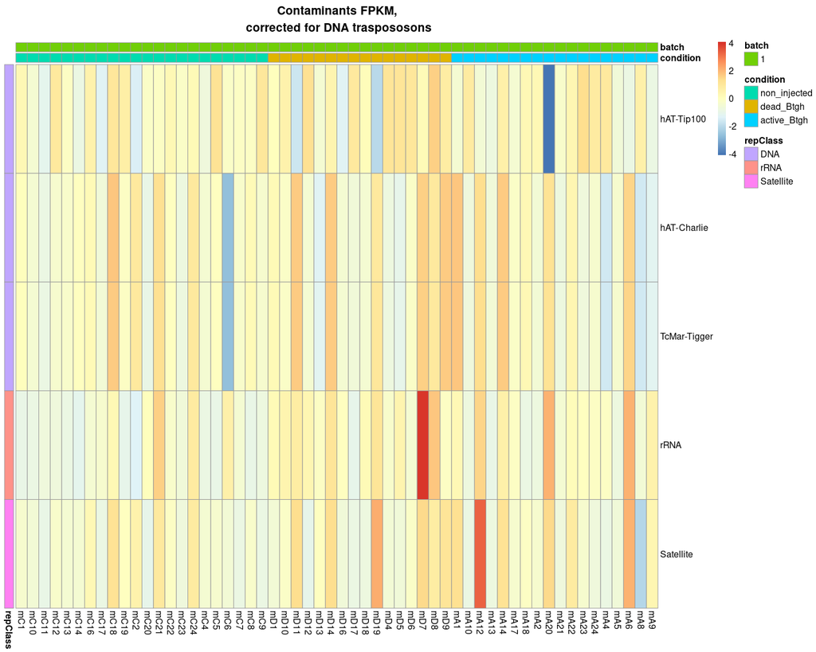

- I exclude samples mA9, mA20 and mC6 from the rest of the TE analysis because more contaminated with DNA transposons.
- No RNA TE family shows deregulation in one of the three experimental groups.

# 3 DE-Seq analysis of RNA transposons

I include the FPKM of DNA repetitive elements as confounding factor in DESeq2 formula.

Before running the Differential Expression analysis, the data are pre-filtered to remove all repetitive elements with < 10 reads among all samples.

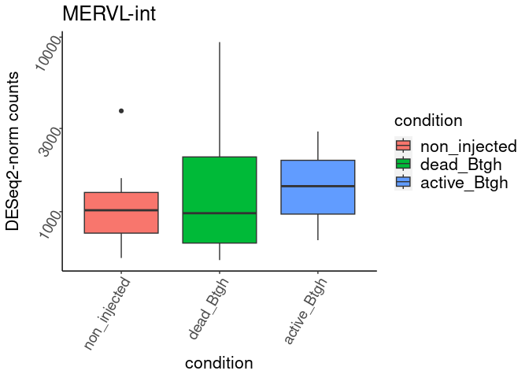

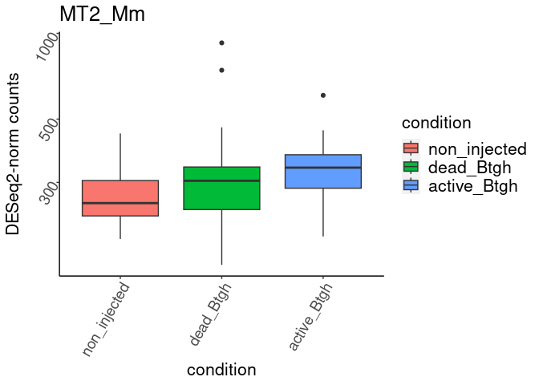

## 3.1 MA-plots

- The threshold used for a dot to be coloured in the MA-plots is p-value adjusted < 0.05.
- Transposable elements whose mean expression > 10 and log2FoldChange > 0.2 (or < -0.2) are labeled.

active vs dead

| baseMean | log2FoldChange | lfcSE | pvalue | padj | repName |
| --- | --- | --- | --- | --- | --- |
| 806.49139 | -0.3778477 | 0.1193406 | 0.0000683 | 0.0116156 | MMETn-int |
| 206.40109 | -0.3818225 | 0.1369757 | 0.0001269 | 0.0116156 | ETnERV-int |
| 3573.42804 | -0.3363603 | 0.1266031 | 0.0004848 | 0.0295735 | B2_Mm1a |
| 498.50741 | -0.3352599 | 0.1495905 | 0.0007787 | 0.0332760 | RLTR10-int |
| 2198.03897 | -0.3218701 | 0.1305130 | 0.0009092 | 0.0332760 | B2_Mm1t |
| 70.57467 | 0.3044471 | 0.1306259 | 0.0016102 | 0.0453632 | L1MdFanc_II |
| 16.97384 | -0.2951958 | 0.1710063 | 0.0019182 | 0.0453632 | RLTR26 |
| 389.54918 | -0.2847695 | 0.1180779 | 0.0019831 | 0.0453632 | L1MdTf_III |

active vs non inj

| baseMean | log2FoldChange | lfcSE | pvalue | padj | repName |
| --- | --- | --- | --- | --- | --- |
| 52.239767 | 0.5380230 | 0.1350304 | 0.0000007 | 0.0001573 | L1_Mur3 |
| 31.009136 | -0.4685576 | 0.1483968 | 0.0000304 | 0.0034974 | RLTR17 |
| 198.441948 | 0.4520685 | 0.2067209 | 0.0000526 | 0.0040305 | MER89 |
| 57.391712 | 0.3619053 | 0.1223337 | 0.0003116 | 0.0179177 | L1Lx_IV |
| 82.818382 | 0.3463769 | 0.1222770 | 0.0005484 | 0.0228044 | ORR1A3-int |
| 120.961862 | -0.3601924 | 0.1321217 | 0.0005949 | 0.0228044 | RLTR13B2 |
| 1010.357509 | 0.3837509 | 0.1613170 | 0.0007645 | 0.0251195 | MTA_Mm-int |
| 389.549176 | -0.3187987 | 0.1148767 | 0.0009187 | 0.0262123 | L1MdTf_III |
| 9.499054 | -0.3721853 | 0.1869677 | 0.0011180 | 0.0262123 | MLTR11B |
| 103.868560 | 0.3480707 | 0.1376616 | 0.0011397 | 0.0262123 | RLTR6-int |
| 14.749991 | 0.3584921 | 0.1790419 | 0.0017506 | 0.0360284 | L1Lx_II |
| 37.170810 | 0.3497443 | 0.1597735 | 0.0019886 | 0.0360284 | MT-int |
| 7.922593 | 0.3294815 | 0.2051498 | 0.0020364 | 0.0360284 | L1_Rod |
| 67.889418 | 0.3314359 | 0.1521968 | 0.0028899 | 0.0464899 | MT2B |
| 61.251019 | 0.2822648 | 0.1134049 | 0.0030320 | 0.0464899 | LTRIS_Mus |

dead vs non inj

| baseMean | log2FoldChange | lfcSE | pvalue | padj | repName |
| --- | --- | --- | --- | --- | --- |

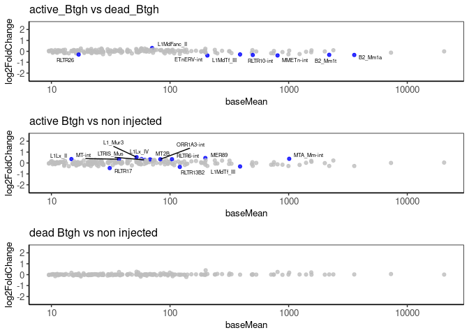